# The Istanbul Metropolitan Municipality Car Park Network "ISPARK" Analysis

*Prepared by Evren Ermis based the data from https://data.ibb.gov.tr/*

[figure not shown]

## 1 - Business Understanding

In this project, ISPARK - Istanbul Park, municipally driven car park company, data has used to analyze Istanbul car park network including parking point cost, usage and location.

In this project; I try to find out the answers of below questions

- How many parking zones do each side of Istanbul have? What is the average monthly subscription cost per side?
- What are the number of parking zones and their monthly costs of each district in Istanbul ?
- What is the average utilization rate and total capacity of parking zones of each district in Istanbul ?
- What are the parking slots that we can stop 15 minutes (or more) freely ?
- Bonus: Create a map plot of parking points regarding their capacity, utilization rate and cost for better location and distribution understanding

## 2 - Project Dependencies

In order to run the notebook flawlessly please run:

```
- pip install plotly==4.9.0
- pip install pandas
- pip install numpy
- pip install matplotlib
- conda install -c plotly plotly-orca==1.3.1 psutil requests
```

## 3 - Explanatory Data Analysis and Insights

### 3.1 - Data Load & Preprocessing

```python
import numpy as np
import pandas as pd
import plotly.graph_objects as go
from plotly.subplots import make_subplots
import matplotlib.pyplot as plt
```

```python
df = pd.read_excel("ibb_ispark.xlsx", sheet_name="İSPARK Otoparklarına Ait B.", index_col = 0)
```

```python
# Lower all columns and put "_" ilo " "
# Drop duplicated parking zones

df.columns = df.columns.str.replace(" ", "_")
df.columns = map(str.lower, df.columns)
df.drop_duplicates(subset="park_adı", keep="first", inplace=True)
```

```python
# Check whether everything is allright

df.head()
```

| Park ID | park_adı | lokasyon_id | lokasyon_kodu | lokasyon_adı | park_tipi_id | park_tipi | park_kapasitesi | calışma_saatleri | bölge_id | bölge | ... | i̇lçe | adres | enlem/boylam | polygon_verisi | boylam | enlem | aylık_abonelik_ücreti | ücretsiz_parklanma_süresi_(dakika) | tarifesi | park_et_devam_et_noktası |
| --- | --- | --- | --- | --- | --- | --- | --- | --- | --- | --- | --- | --- | --- | --- | --- | --- | --- | --- | --- | --- | --- |
| 359 | Atatürk Bulvarı 1 | 150 | 1 | 0001 Atatürk Bulvarı 1 | 2 | YOL ÜSTÜ | 18 | 07:30-18:30 | 4 | Avrupa | ... | FATİH | KEMALPAŞA MAHALLESİ ATATÜRK BULVARI 1 / EMİNÖNÜ | POINT (28.953538299155497 41.011291499669255) | MULTIPOLYGON (((28.95351077 41.01117896, 28.95... | 28.953538 | 41.011291 | 0.0 | 15.0 | 0-1 Saat : 10,00;1-2 Saat : 11,00;2-4 Saat ... | 0 |
| 860 | Bakırköy İstanbul Caddesi 1 | 384 | 2 | 0002 Bakırköy İstanbul Caddesi | 2 | YOL ÜSTÜ | 30 | 08:00-19:00 | 4 | Avrupa | ... | BAKIRKÖY | YEŞİLKÖY MAHALLESİ İSTANBUL CADDESİ ÜZERİ BAKI... | POINT (28.8747420429072 40.97837155571149) | MULTIPOLYGON (((28.87445897 40.97835591, 28.87... | 28.874742 | 40.978372 | 400.0 | 15.0 | 0-1 Saat : 10,00;1-2 Saat : 12,00;2-4 Saat ... | 0 |
| 861 | Bakırköy İstanbul Caddesi 2 | 384 | 2 | 0002 Bakırköy İstanbul Caddesi | 2 | YOL ÜSTÜ | 30 | 08:00-19:00 | 4 | Avrupa | ... | BAKIRKÖY | YEŞİLKÖY MAHALLESİ İSTANBUL CADDESİ ÜZERİ BAKI... | POINT (28.875321425593391 40.97841938898064) | MULTIPOLYGON (((28.87546464 40.97842251, 28.87... | 28.875321 | 40.978419 | 400.0 | 15.0 | 0-1 Saat : 10,00;1-2 Saat : 12,00;2-4 Saat ... | 0 |
| 862 | Bakırköy İstanbul Caddesi 3 | 384 | 2 | 0002 Bakırköy İstanbul Caddesi | 2 | YOL ÜSTÜ | 70 | 08:00-19:00 | 4 | Avrupa | ... | BAKIRKÖY | YEŞİLKÖY MAHALLESİ İSTANBUL CADDESİ ÜZERİ BAKI... | POINT (28.87595720460348 40.978472523602171) | MULTIPOLYGON (((28.87628195 40.9784853, 28.876... | 28.875957 | 40.978473 | 400.0 | 15.0 | 0-1 Saat : 10,00;1-2 Saat : 12,00;2-4 Saat ... | 0 |
| 867 | Bakırköy İstanbul Caddesi 8 | 384 | 2 | 0002 Bakırköy İstanbul Caddesi | 2 | YOL ÜSTÜ | 40 | 08:00-19:00 | 4 | Avrupa | ... | BAKIRKÖY | YEŞİLKÖY MAHALLESİ İSTANBUL CADDESİ ÜZERİ BAKI... | POINT (28.878947832742334 40.978643838182634) | MULTIPOLYGON (((28.87909771 40.97868195, 28.87... | 28.878948 | 40.978644 | 400.0 | 15.0 | 0-1 Saat : 10,00;1-2 Saat : 12,00;2-4 Saat ... | 0 |

5 rows × 23 columns

### 3.2 - Side Comparison Analysis by Parking Zone Count and Monthly Subscription Cost

```python
df.groupby("bölge")["aylık_abonelik_ücreti"].mean().round(0).sort_values(ascending=False)
```

```
bölge
Avrupa     174.0
Anadolu    130.0
Name: aylık_abonelik_ücreti, dtype: float64
```

```python
df.groupby("bölge")["lokasyon_id"].count().sort_values(ascending=False)
```

```
bölge
Avrupa     481
Anadolu    205
Name: lokasyon_id, dtype: int64
```

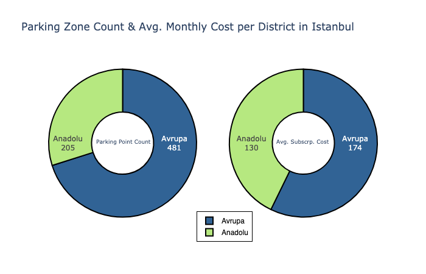

```python
# Parking zone count per side
side_name = df.groupby("bölge")["lokasyon_id"].count().sort_values(ascending=False).index
side_park_count = df.groupby("bölge")["lokasyon_id"].count().sort_values(ascending=False).values

# Avg monthly subscription cost per side
side_name_cost = df.groupby("bölge")["aylık_abonelik_ücreti"].mean().round(0).sort_values(ascending=False).index
side_avg_cost = df.groupby("bölge")["aylık_abonelik_ücreti"].mean().round(0).sort_values(ascending=False).values


colors = ["#316395", "#B6E880"]
fig = make_subplots(rows=1, cols=2, specs = [[{'type':'domain'}, {'type':'domain'}]])

fig.add_trace(go.Pie(labels=side_name, values=side_park_count, textinfo='label+value',
                             insidetextorientation='radial', hole=.42,
                             marker=dict(colors=colors, line=dict(color='#000000', width=2))
                            ),row=1, col=1)

fig.add_trace(go.Pie(labels=side_name_cost, values=side_avg_cost, textinfo='label+value',
                             insidetextorientation='radial', hole=.42,
                             marker=dict(colors=colors, line=dict(color='#000000', width=2))
                            ), row=1, col=2)
fig.update_layout(

    title = "Parking Zone Count & Avg. Monthly Cost per District in Istanbul",
    legend=dict(
        x=0.45,
        y=-0.1,
        traceorder="normal",
        font=dict(
            family="sans-serif",
            size=12,
            color="black"
        ),
        bgcolor="White",
        bordercolor="Black",
        borderwidth=1
    ),

    annotations=[dict(text='Parking Point Count', x=0.14, y=0.51, font_size=9, showarrow=False),
                 dict(text='Avg. Subscrp. Cost', x=0.855, y=0.51, font_size=9, showarrow=False)]
)

fig.show("png")
```

### Outcome

Apparently, European Side of Istanbul have 2x of parking zones in comparison to Anatolian Side and the parking zones in European Side are expensive than Anatolian Side considering monthly subscription cost.

### 3.3 - District Comparison Analysis by Parking Zone Count and Monthly Subscription Cost

```python
# Split data into sides of Istanbul to illustrate district's number of parking zone and
# average monthly subscription cost

df_avp = df[df["bölge"]=="Avrupa"]
df_and = df[df["bölge"]=="Anadolu"]

# European Side dataframe creation
avp_location = df_avp.groupby("i̇lçe")["lokasyon_id"].count().index
avp_count = df_avp.groupby("i̇lçe")["lokasyon_id"].count().values
avp_cost = df_avp.groupby("i̇lçe")["aylık_abonelik_ücreti"].mean().round(0).values
df_avp_final = pd.DataFrame({"location": avp_location, "park_count": avp_count, "park_avg_monthly_cost":avp_cost})

# Anatolian Side dataframe creation
and_location = df_and.groupby("i̇lçe")["lokasyon_id"].count().index
and_count = df_and.groupby("i̇lçe")["lokasyon_id"].count().values
and_cost = df_and.groupby("i̇lçe")["aylık_abonelik_ücreti"].mean().round(0).values
df_and_final = pd.DataFrame({"location": and_location, "park_count": and_count, "park_avg_monthly_cost":and_cost})
```

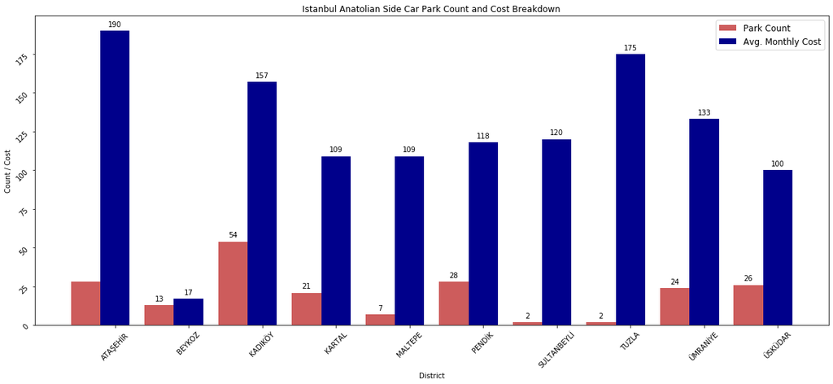

```python
# Anatolian Side district parking zone count and cost breakdown
fig, ax = plt.subplots(figsize=(20,8))

x = np.arange(len(df_and_final["location"]))
width = 0.40 # width of bar

xs = df_and_final["location"]
ys_1 = df_and_final["park_count"]
ys_2 = df_and_final["park_avg_monthly_cost"]


ax.bar(x, ys_1, color= "indianred", align='center', width=width, label="Park Count")
ax.bar(x + width , ys_2, color= "darkblue", align='center', width=width, label="Avg. Monthly Cost")

ax.set_title("Istanbul Anatolian Side Car Park Count and Cost Breakdown")
ax.set_xlabel('District')
ax.set_ylabel('Count / Cost')

ax.set_xticklabels(xs)
ax.set_xticks(x + width)
ax.tick_params(rotation=45)

# Annotation link: https://stackoverflow.com/questions/43554521/add-data-label-to-grouped-bar-chart-in-matplotlib
for p in ax.patches[1:]:
    h = p.get_height()
    x = p.get_x()+p.get_width()/2.
    if h != 0:
        ax.annotate("%g" % p.get_height(), xy=(x,h), xytext=(0,4),
                   textcoords="offset points", ha="center", va="bottom")

ax.legend(loc="upper right", fontsize="large")
plt.show()
```

### Outcome

As we seen on the above graph, Kadıköy leads in number of parking zone in Anatolian side with 54 different parking zones. Sultanbeyli, Tuzla and Maltepe have limited number of parking zones.  
Although only 2 parking zones exist in Tuzla, they have the second most expensive monthly subscription cost. In Anatolian side, the most expensive parking zones are located in Ataşehir.

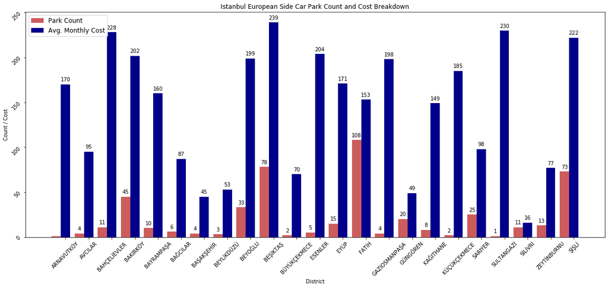

```python
# European Side district parking zone count and cost breakdown

fig, ax = plt.subplots(figsize=(20,8))

x = np.arange(len(df_avp_final["location"]))
width = 0.40 # width of bar

xs = df_avp_final["location"]
ys_1 = df_avp_final["park_count"]
ys_2 = df_avp_final["park_avg_monthly_cost"]


ax.bar(x, ys_1, color= "indianred", align='center', width=width, label="Park Count")
ax.bar(x + width , ys_2, color= "darkblue", align='center', width=width, label="Avg. Monthly Cost")

ax.set_title("Istanbul European Side Car Park Count and Cost Breakdown")
ax.set_xlabel('District')
ax.set_ylabel('Count / Cost')

ax.set_xticklabels(xs)
ax.set_xticks(x + width)
ax.tick_params(rotation=45)

# Annotation link: https://stackoverflow.com/questions/43554521/add-data-label-to-grouped-bar-chart-in-matplotlib
for p in ax.patches[1:]:
    h = p.get_height()
    x = p.get_x()+p.get_width()/2.
    if h != 0:
        ax.annotate("%g" % p.get_height(), xy=(x,h), xytext=(0,4),
                   textcoords="offset points", ha="center", va="bottom")

ax.legend(loc="upper left", fontsize="large")
plt.show()
```

```python
df.drop(df[round(df["enlem"])==29].index, inplace=True)
```

```python
info = ((df["boylam"].min(), df["boylam"].max(),
         df["enlem"].min(),   df["enlem"].max()))

info
```

```
(28.2434800707908, 29.3268173933029, 40.8150088134286, 41.1967928344884)
```

### Live Status of Parking Zones (28-July-2020 / 22:01 TR Time)

```python
"""
Get API Request to IBB Data Center to extract live status of parking zones.
"""


import requests
r = requests.get("https://api.ibb.gov.tr/ispark/Park")
df_live = pd.DataFrame.from_dict(r.json())
```

```python
df_live.columns = df_live.columns.str.replace(" ", "_")
df_live.columns = map(str.lower, df_live.columns)
df_live.drop_duplicates(subset="parkadi", keep="first", inplace=True)
```

```python
# Check whether everything is OK

df_live.head()
```

|  | parkid | parkadi | latitude | longitude | kapasitesi | boskapasite | parktipi | ilce | distance | ucretsizparklanmadk |
| --- | --- | --- | --- | --- | --- | --- | --- | --- | --- | --- |
| 0 | 395 | Yeşil Vadi Sokak 4 | 40.9670716467854 | 29.1058243767132 | 40 | 28 | YOL ÜSTÜ | ATAŞEHİR | 0.372 | 15 |
| 1 | 1189 | İçerenköy Açık Otoparkı 1 | 40.9765973901075 | 29.1045454144478 | 600 | 599 | AÇIK OTOPARK | ATAŞEHİR | 0.696 | 15 |
| 2 | 2151 | Bostancı Vergi Dairesi Açık Otoparkı | 40.9625308244579 | 29.1079999343615 | 105 | 105 | AÇIK OTOPARK | ATAŞEHİR | 0.907 | 0 |
| 4 | 1176 | Kozyatağı Sebze-Meyve Hali | 40.978484297008 | 29.1029469575332 | 1500 | 1500 | AÇIK OTOPARK | ATAŞEHİR | 0.918 | 0 |
| 5 | 1208 | Bostancı İdo ve Adalar İskelesi Önü Taksi Durağı | 40.952526073751 | 29.0937899011629 | 16 | 16 | TAKSİ PARK | KADIKÖY | 2.180 | 0 |

```python
# Calculate %Utilization & in use capacity per parking zone

df_live["utilization"] = (100 - (round((df_live["boskapasite"] / df_live["kapasitesi"])*100,0)))
df_live["in_use_capacity"] = df_live["kapasitesi"] - df_live["boskapasite"]
```

```python
# Check whether everything is OK

df_live.head()
```

|  | parkid | parkadi | latitude | longitude | kapasitesi | boskapasite | parktipi | ilce | distance | ucretsizparklanmadk | utilization | in_use_capacity |
| --- | --- | --- | --- | --- | --- | --- | --- | --- | --- | --- | --- | --- |
| 0 | 395 | Yeşil Vadi Sokak 4 | 40.9670716467854 | 29.1058243767132 | 40 | 28 | YOL ÜSTÜ | ATAŞEHİR | 0.372 | 15 | 30.0 | 12 |
| 1 | 1189 | İçerenköy Açık Otoparkı 1 | 40.9765973901075 | 29.1045454144478 | 600 | 599 | AÇIK OTOPARK | ATAŞEHİR | 0.696 | 15 | 0.0 | 1 |
| 2 | 2151 | Bostancı Vergi Dairesi Açık Otoparkı | 40.9625308244579 | 29.1079999343615 | 105 | 105 | AÇIK OTOPARK | ATAŞEHİR | 0.907 | 0 | 0.0 | 0 |
| 4 | 1176 | Kozyatağı Sebze-Meyve Hali | 40.978484297008 | 29.1029469575332 | 1500 | 1500 | AÇIK OTOPARK | ATAŞEHİR | 0.918 | 0 | 0.0 | 0 |
| 5 | 1208 | Bostancı İdo ve Adalar İskelesi Önü Taksi Durağı | 40.952526073751 | 29.0937899011629 | 16 | 16 | TAKSİ PARK | KADIKÖY | 2.180 | 0 | 0.0 | 0 |

### 3.4 - In Use Capacity, Utilization and Overall Capacity Analysis per District

```python
# Create a dataset contains avg utilization, in use capacity and overall capacity per district

df_district_capacity = pd.DataFrame({"location":df_live.groupby("ilce")["kapasitesi"].sum().index,
                                    "total_capacity":df_live.groupby("ilce")["kapasitesi"].sum().values})

df_district_in_use_capacity = pd.DataFrame({"location":df_live.groupby("ilce")["in_use_capacity"].sum().index,
                                    "in_use":df_live.groupby("ilce")["in_use_capacity"].sum().values})

df_district = pd.DataFrame({"location":df_live.groupby("ilce")["utilization"].mean().sort_values(ascending=False).index,
                            "avg_utilization": round(df_live.groupby("ilce")["utilization"].mean(),1).sort_values(ascending=False).values}
                          )

df_district = df_district.merge(df_district_in_use_capacity, on="location")
df_district = df_district.merge(df_district_capacity, on="location")
df_district.head(20).style.background_gradient(cmap='Blues')
```

|  | location | avg_utilization | in_use | total_capacity |
| --- | --- | --- | --- | --- |
| 0 | SULTANBEYLİ | 54 | 199 | 430 |
| 1 | BAYRAMPAŞA | 51.7 | 3291 | 4252 |
| 2 | BAŞAKŞEHİR | 49.5 | 147 | 355 |
| 3 | ESENLER | 47.8 | 804 | 1694 |
| 4 | KARTAL | 41.5 | 803 | 2014 |
| 5 | BÜYÜKÇEKMECE | 40 | 55 | 140 |
| 6 | TUZLA | 39.5 | 239 | 600 |
| 7 | KADIKÖY | 39.4 | 3482 | 6090 |
| 8 | BEYKOZ | 38 | 249 | 1103 |
| 9 | EYÜP | 36.4 | 4909 | 15527 |
| 10 | GAZİOSMANPAŞA | 33.5 | 20 | 60 |
| 11 | ŞİŞLİ | 31.8 | 1031 | 4118 |
| 12 | ÜSKÜDAR | 31.5 | 949 | 2615 |
| 13 | ÜMRANİYE | 30.7 | 456 | 1375 |
| 14 | BEŞİKTAŞ | 29.9 | 746 | 5816 |
| 15 | PENDİK | 28.6 | 1096 | 4238 |
| 16 | MALTEPE | 28.2 | 374 | 3385 |
| 17 | BEYOĞLU | 25.8 | 1196 | 3616 |
| 18 | KAĞITHANE | 25.7 | 237 | 3103 |
| 19 | ZEYTİNBURNU | 24.3 | 1215 | 6055 |

### Outcome

As of 28-July-2020 / 22:01 TR Time, there is no overload observed regarding utilization.  
Utilization can / should be deeply investigated by repeating above analysis on different times of a day. Since today is weekday and time is late, depending just this data might mislead us from that reason we should collect more data in order to determine utilization status. Nevertheless, above graph is a good snapshot of a weekday night !

### 3.5 - 15 Minutes Free Stopping

```python
df_live[df_live["ucretsizparklanmadk"] >= 15].sort_values(by="ucretsizparklanmadk", ascending=False).head(20)[{"parkadi", "ucretsizparklanmadk"}].style.background_gradient(cmap='Greens')
```

|  | parkadi | ucretsizparklanmadk |
| --- | --- | --- |
| 590 | İspark West İstanbul Marina Açık Otoparkı | 120 |
| 505 | 15 Temmuz Demokrasi Otogarı | 60 |
| 544 | EGS Blokları Açık Otoparkı | 60 |
| 525 | Okan Üniversitesi Zemin Altı Otoparkı | 30 |
| 478 | Alibeyköy Cep Otogarı Açık Otoparkı | 30 |
| 420 | Beykoz Sosyal Tesisleri 1 | 30 |
| 423 | Beykoz Sosyal Tesisleri 2 | 30 |
| 64 | Eski Salı Pazarı | 20 |
| 97 | Çengelköy Açık Otoparkı | 20 |
| 395 | Çınar Açık Otoparkı | 15 |
| 405 | Pendik Sahil İdo Açık Otoparkı | 15 |
| 404 | Akçam Sokak (İş Bankası Önü) 1 | 15 |
| 402 | Meydan Otoparkı Akçam Sokak | 15 |
| 399 | Selvi Sokak 1 | 15 |
| 397 | Pendik Ankara Caddesi 3 | 15 |
| 396 | Pendik Ankara Caddesi 1 | 15 |
| 0 | Yeşil Vadi Sokak 4 | 15 |
| 394 | Pendik 23 Nisan Caddesi 1 | 15 |
| 407 | Pendik Marina 2 | 15 |
| 393 | Pendik 23 Nisan Caddesi 2 | 15 |

### Outcome

Ispark West Istanbul Marina, 15 Temmuz Demokrasi Otogarı and EGS Blokları Açık Otoparkı have the most free stop time in Istanbul. Others can be seen on the above list.